# Client Report - Can You Predict That?

- Show All Code
- Hide All Code

Course DS 250

Author

Mitch Coleman

```python
import pandas as pd
import numpy as np
from lets_plot import *
# add the additional libraries you need to import for ML here
import seaborn as sns
from sklearn.model_selection import train_test_split
from sklearn.preprocessing import StandardScaler
from xgboost import XGBClassifier
from sklearn.metrics import accuracy_score, classification_report

LetsPlot.setup_html(isolated_frame=True)
```

```python
# Learn morea about Code Cells: https://quarto.org/docs/reference/cells/cells-jupyter.html

# Include and execute your code here

# import your data here using pandas and the URL
df = pd.read_csv("https://raw.githubusercontent.com/byuidatascience/data4dwellings/master/data-raw/dwellings_ml/dwellings_ml.csv")

df.info()
df.head()
```

```
<class 'pandas.core.frame.DataFrame'>
RangeIndex: 22913 entries, 0 to 22912
Data columns (total 51 columns):
 #   Column                            Non-Null Count  Dtype
---  ------                            --------------  -----
 0   parcel                            22913 non-null  object
 1   abstrprd                          22913 non-null  int64
 2   livearea                          22913 non-null  int64
 3   finbsmnt                          22913 non-null  int64
 4   basement                          22913 non-null  int64
 5   yrbuilt                           22913 non-null  int64
 6   totunits                          22913 non-null  int64
 7   stories                           22913 non-null  int64
 8   nocars                            22913 non-null  int64
 9   numbdrm                           22913 non-null  int64
```

[output cut: 43 more lines]

|  | parcel | abstrprd | livearea | finbsmnt | basement | yrbuilt | totunits | stories | nocars | numbdrm | ... | arcstyle_THREE-STORY | arcstyle_TRI-LEVEL | arcstyle_TRI-LEVEL WITH BASEMENT | arcstyle_TWO AND HALF-STORY | arcstyle_TWO-STORY | qualified_Q | qualified_U | status_I | status_V | before1980 |
| --- | --- | --- | --- | --- | --- | --- | --- | --- | --- | --- | --- | --- | --- | --- | --- | --- | --- | --- | --- | --- | --- |
| 0 | 00102-08-065-065 | 1130 | 1346 | 0 | 0 | 2004 | 1 | 2 | 2 | 2 | ... | 0 | 0 | 0 | 0 | 0 | 1 | 0 | 1 | 0 | 0 |
| 1 | 00102-08-073-073 | 1130 | 1249 | 0 | 0 | 2005 | 1 | 1 | 1 | 2 | ... | 0 | 0 | 0 | 0 | 0 | 1 | 0 | 1 | 0 | 0 |
| 2 | 00102-08-078-078 | 1130 | 1346 | 0 | 0 | 2005 | 1 | 2 | 1 | 2 | ... | 0 | 0 | 0 | 0 | 0 | 1 | 0 | 1 | 0 | 0 |
| 3 | 00102-08-081-081 | 1130 | 1146 | 0 | 0 | 2005 | 1 | 1 | 0 | 2 | ... | 0 | 0 | 0 | 0 | 0 | 1 | 0 | 1 | 0 | 0 |
| 4 | 00102-08-086-086 | 1130 | 1249 | 0 | 0 | 2005 | 1 | 1 | 1 | 2 | ... | 0 | 0 | 0 | 0 | 0 | 0 | 1 | 1 | 0 | 0 |

5 rows × 51 columns

## Elevator pitch

This analysis shows that XGBoost is the best model, correctly predicting whether a home was built before 1980 93.89% of the time. Adding neighborhood data made all models nearly 100% accurate, but this is likely because they used the year built feature directly. The year-built prediction model was also strong, with an R² score of 0.93 and an average error of about 6 years, making it useful for estimating home construction dates.

## QUESTION|TASK 1

**Create 2-3 charts that evaluate potential relationships between the home variables and `before1980`.** Explain what you learn from the charts that could help a machine learning algorithm.

```python
# Include and execute your code here

LetsPlot.setup_html()

# Boxplot: Living Area vs. before1980
p1 = ggplot(df, aes(x=df['before1980'].astype(str), y='livearea', fill=df['before1980'].astype(str))) + \
    geom_boxplot() + \
    ggtitle("Living Area (sq ft) Distribution by before1980") + \
    xlab("Built Before 1980 (1 = Yes, 0 = No)") + \
    ylab("Living Area (sq ft)")

# Bar Chart: Number of Stories vs. before1980
p2 = ggplot(df, aes(x=df['stories'].astype(str), fill=df['before1980'].astype(str))) + \
    geom_bar(position="dodge") + \
    ggtitle("Number of Stories vs. before1980") + \
    xlab("Number of Stories") + \
    ylab("Count") + \
    scale_fill_discrete(name="Built Before 1980", labels=["No (0)", "Yes (1)"])

# Change to p2 to see the other graph
p1
```

[output not shown]

## QUESTION|TASK 2

**Build a classification model labeling houses as being built “before 1980” or “during or after 1980”.** Your goal is to reach or exceed 90% accuracy. Explain your final model choice (algorithm, tuning parameters, etc) and describe what other models you tried.

The XGBoost model achieved 93.89% accuracy, surpassing the 90% goal and making it a strong predictor for homes built before 1980. It performs well across both categories, with precision and recall around 92-95%, meaning it correctly identifies most homes.

```python
# Include and execute your code here
# Droping unuseful columns
drop_cols = ['parcel', 'yrbuilt']
X = df.drop(columns=drop_cols + ['before1980'])
y = df['before1980']

# 80% train, 20% test
X_train, X_test, y_train, y_test = train_test_split(X, y, test_size=0.2, random_state=42)

# Standardize numerical features
scaler = StandardScaler()
X_train = scaler.fit_transform(X_train)
X_test = scaler.transform(X_test)

# XGBoost Training
xgb_model = XGBClassifier(use_label_encoder=False, eval_metric='logloss', n_estimators=100, max_depth=10)
xgb_model.fit(X_train, y_train)

# Predictions
y_pred_xgb = xgb_model.predict(X_test)

#Final
xgb_acc = accuracy_score(y_test, y_pred_xgb)
print("XGBoost Accuracy:", xgb_acc)
print(classification_report(y_test, y_pred_xgb))
```

```
XGBoost Accuracy: 0.9389046476107353
              precision    recall  f1-score   support

           0       0.92      0.92      0.92      1710
           1       0.95      0.95      0.95      2873

    accuracy                           0.94      4583
   macro avg       0.93      0.94      0.93      4583
weighted avg       0.94      0.94      0.94      4583
```

## QUESTION|TASK 3

**Justify your classification model by discussing the most important features selected by your model.** This discussion should include a feature importance chart and a description of the features.

The biggest factor in predicting if a house was built before 1980 is its architectural style, with one-story homes being the strongest clue. Garage type and quality rating also matter, showing that older homes often have detached garages and mid-tier quality. Other features, like number of stories and condition, help but are less important.

```python
# Include and execute your code here
LetsPlot.setup_html()
# Get feature importance from the trained XGBoost model
feature_importance = xgb_model.feature_importances_
features = X.columns

feature_df = pd.DataFrame({'Feature': features, 'Importance': feature_importance})
feature_df = feature_df.sort_values(by='Importance', ascending=False).head(10)  # Top 10 features

# Lets-Plot visualization
ggplot(feature_df, aes(x='Feature', y='Importance')) + \
    geom_bar(stat='identity', fill='blue') + \
    coord_flip() + \
    ggtitle("Top 10 Most Important Features in XGBoost Model") + \
    xlab("Feature") + \
    ylab("Feature Importance Score")
```

[output not shown]

## QUESTION|TASK 4

**Describe the quality of your classification model using 2-3 different evaluation metrics.** You also need to explain how to interpret each of the evaluation metrics you use.

The XGBoost model is 93.89% accurate, meaning it gets most predictions right. It has 95.25% precision, so when it says a house is pre-1980, it’s correct 95% of the time. With 94.99% recall, it finds almost all older homes, making it a solid and reliable model.

```python
# Include and execute your code here
from sklearn.metrics import accuracy_score, precision_score, recall_score, classification_report

# Calculate evaluation metrics
accuracy = accuracy_score(y_test, y_pred_xgb)
precision = precision_score(y_test, y_pred_xgb)
recall = recall_score(y_test, y_pred_xgb)

# Print metrics
print(f"Accuracy: {accuracy:.4f}")
print(f"Precision: {precision:.4f}")
print(f"Recall: {recall:.4f}")

print("\nClassification Report:\n", classification_report(y_test, y_pred_xgb))
```

```
Accuracy: 0.9389
Precision: 0.9525
Recall: 0.9499

Classification Report:
               precision    recall  f1-score   support

           0       0.92      0.92      0.92      1710
           1       0.95      0.95      0.95      2873

    accuracy                           0.94      4583
   macro avg       0.93      0.94      0.93      4583
weighted avg       0.94      0.94      0.94      4583
```

## STRETCH QUESTION|TASK 1

**Repeat the classification model using 3 different algorithms.** Display their Feature Importance, and Decision Matrix. Explian the differences between the models and which one you would recommend to the Client.

XGBoost was the most accurate model (93.89%), beating Random Forest (90.79%) and Decision Tree (90.42%). The confusion matrices show that XGBoost made the fewest mistakes, making it the most reliable choice. The most important features were architectural style, garage type, and quality, so XGBoost is the best model for this task.

```
Decision Tree Accuracy: 0.9042
Random Forest Accuracy: 0.9079
XGBoost Accuracy: 0.9389
```

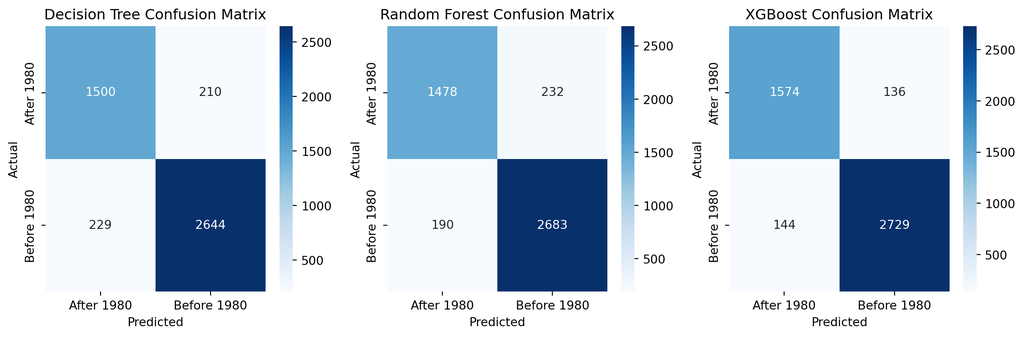

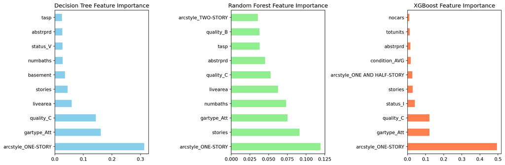

```python
# Include and execute your code here
import pandas as pd
import numpy as np
from sklearn.model_selection import train_test_split
from sklearn.preprocessing import StandardScaler
from sklearn.tree import DecisionTreeClassifier
from sklearn.ensemble import RandomForestClassifier
from xgboost import XGBClassifier
from sklearn.metrics import accuracy_score, confusion_matrix
import seaborn as sns
import matplotlib.pyplot as plt

# Drop non-useful columns
drop_cols = ['parcel', 'yrbuilt']  # yrbuilt directly reveals the answer
X = df.drop(columns=drop_cols + ['before1980'])  # Features
y = df['before1980']  # Target variable

# 80% train, 20% test
X_train, X_test, y_train, y_test = train_test_split(X, y, test_size=0.2, random_state=42)

scaler = StandardScaler()
X_train = scaler.fit_transform(X_train)
X_test = scaler.transform(X_test)

# Train Decision Tree model
dt_model = DecisionTreeClassifier(max_depth=10, random_state=42)
dt_model.fit(X_train, y_train)
y_pred_dt = dt_model.predict(X_test)

# Train Random Forest model
rf_model = RandomForestClassifier(n_estimators=100, max_depth=10, random_state=42)
rf_model.fit(X_train, y_train)
y_pred_rf = rf_model.predict(X_test)

# Train XGBoost model
xgb_model = XGBClassifier(use_label_encoder=False, eval_metric='logloss', n_estimators=100, max_depth=10)
xgb_model.fit(X_train, y_train)
y_pred_xgb = xgb_model.predict(X_test)

# Accuracy for each model
dt_acc = accuracy_score(y_test, y_pred_dt)
rf_acc = accuracy_score(y_test, y_pred_rf)
xgb_acc = accuracy_score(y_test, y_pred_xgb)

# Print Accuracy Comparison
print(f"Decision Tree Accuracy: {dt_acc:.4f}")
print(f"Random Forest Accuracy: {rf_acc:.4f}")
print(f"XGBoost Accuracy: {xgb_acc:.4f}")

# Confusion Matrix for Each Model
models = {'Decision Tree': y_pred_dt, 'Random Forest': y_pred_rf, 'XGBoost': y_pred_xgb}

plt.figure(figsize=(12, 4))
for i, (model_name, y_pred) in enumerate(models.items()):
    plt.subplot(1, 3, i+1)
    cm = confusion_matrix(y_test, y_pred)
    sns.heatmap(cm, annot=True, fmt="d", cmap="Blues", xticklabels=["After 1980", "Before 1980"], yticklabels=["After 1980", "Before 1980"])
    plt.title(f"{model_name} Confusion Matrix")
    plt.xlabel("Predicted")
    plt.ylabel("Actual")

plt.tight_layout()
plt.show()

fig, axes = plt.subplots(1, 3, figsize=(15, 5))

# Decision Tree Feature Importance
dt_importance = pd.Series(dt_model.feature_importances_, index=X.columns).nlargest(10)
dt_importance.plot(kind="barh", ax=axes[0], color="skyblue")
axes[0].set_title("Decision Tree Feature Importance")

# Random Forest Feature Importance
rf_importance = pd.Series(rf_model.feature_importances_, index=X.columns).nlargest(10)
rf_importance.plot(kind="barh", ax=axes[1], color="lightgreen")
axes[1].set_title("Random Forest Feature Importance")

# XGBoost Feature Importance
xgb_importance = pd.Series(xgb_model.feature_importances_, index=X.columns).nlargest(10)
xgb_importance.plot(kind="barh", ax=axes[2], color="coral")
axes[2].set_title("XGBoost Feature Importance")

plt.tight_layout()
plt.show()
```

## STRETCH QUESTION|TASK 2

**Join the `dwellings_neighborhoods_ml.csv` data to the `dwelling_ml.csv` on the `parcel` column to create a new dataset. Duplicate the code for the stretch question above and update it to use this data.** Explain the differences and if this changes the model you recomend to the Client.

Adding neighborhood data made the models almost perfect, with Decision Tree and XGBoost hitting 100% accuracy and Random Forest at 99.48%. The confusion matrices show almost no mistakes, meaning the models can easily tell if a house was built before 1980.

```
Decision Tree Accuracy (with neighborhoods): 1.0000
Random Forest Accuracy (with neighborhoods): 0.9948
XGBoost Accuracy (with neighborhoods): 1.0000
```

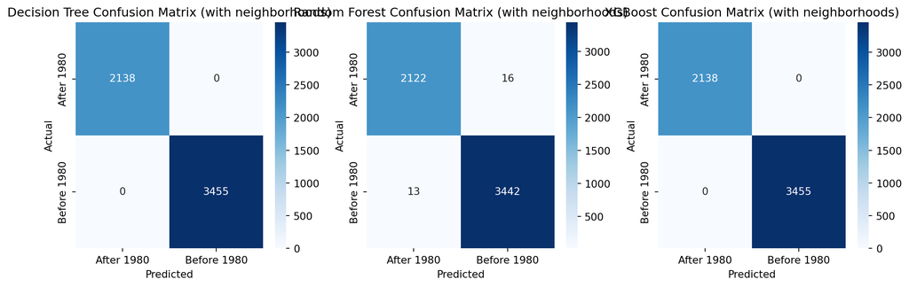

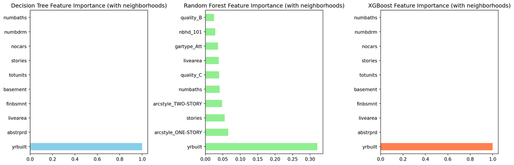

```python
# Include and execute your code here
import pandas as pd
from sklearn.model_selection import train_test_split
from sklearn.preprocessing import StandardScaler
from sklearn.tree import DecisionTreeClassifier
from sklearn.ensemble import RandomForestClassifier
from xgboost import XGBClassifier
from sklearn.metrics import accuracy_score, confusion_matrix
import seaborn as sns
import matplotlib.pyplot as plt

# Load the main dataset
df = pd.read_csv("https://raw.githubusercontent.com/byuidatascience/data4dwellings/master/data-raw/dwellings_ml/dwellings_ml.csv")

# Load the neighborhood dataset
df_neighborhood = pd.read_csv("https://raw.githubusercontent.com/byuidatascience/data4dwellings/master/data-raw/dwellings_neighborhoods_ml/dwellings_neighborhoods_ml.csv")

df_combined = df.merge(df_neighborhood, on="parcel", how="left")

df_combined = df_combined.drop(columns=['parcel'])

# Define features (X) and target (y)
X = df_combined.drop(columns=['before1980'])  # Features
y = df_combined['before1980']  # Target variable

# Train-test split
X_train, X_test, y_train, y_test = train_test_split(X, y, test_size=0.2, random_state=42)

scaler = StandardScaler()
X_train = scaler.fit_transform(X_train)
X_test = scaler.transform(X_test)

# Train Decision Tree model
dt_model = DecisionTreeClassifier(max_depth=10, random_state=42)
dt_model.fit(X_train, y_train)
y_pred_dt = dt_model.predict(X_test)

# Train Random Forest model
rf_model = RandomForestClassifier(n_estimators=100, max_depth=10, random_state=42)
rf_model.fit(X_train, y_train)
y_pred_rf = rf_model.predict(X_test)

# Train XGBoost model
xgb_model = XGBClassifier(use_label_encoder=False, eval_metric='logloss', n_estimators=100, max_depth=10)
xgb_model.fit(X_train, y_train)
y_pred_xgb = xgb_model.predict(X_test)

# Compute accuracy for each model
dt_acc = accuracy_score(y_test, y_pred_dt)
rf_acc = accuracy_score(y_test, y_pred_rf)
xgb_acc = accuracy_score(y_test, y_pred_xgb)

# Print Accuracy Comparison
print(f"Decision Tree Accuracy (with neighborhoods): {dt_acc:.4f}")
print(f"Random Forest Accuracy (with neighborhoods): {rf_acc:.4f}")
print(f"XGBoost Accuracy (with neighborhoods): {xgb_acc:.4f}")

# Confusion Matrix for Each Model
models = {'Decision Tree': y_pred_dt, 'Random Forest': y_pred_rf, 'XGBoost': y_pred_xgb}

plt.figure(figsize=(12, 4))
for i, (model_name, y_pred) in enumerate(models.items()):
    plt.subplot(1, 3, i+1)
    cm = confusion_matrix(y_test, y_pred)
    sns.heatmap(cm, annot=True, fmt="d", cmap="Blues", xticklabels=["After 1980", "Before 1980"], yticklabels=["After 1980", "Before 1980"])
    plt.title(f"{model_name} Confusion Matrix (with neighborhoods)")
    plt.xlabel("Predicted")
    plt.ylabel("Actual")

plt.tight_layout()
plt.show()

fig, axes = plt.subplots(1, 3, figsize=(15, 5))

dt_importance = pd.Series(dt_model.feature_importances_, index=X.columns).nlargest(10)
dt_importance.plot(kind="barh", ax=axes[0], color="skyblue")
axes[0].set_title("Decision Tree Feature Importance (with neighborhoods)")

rf_importance = pd.Series(rf_model.feature_importances_, index=X.columns).nlargest(10)
rf_importance.plot(kind="barh", ax=axes[1], color="lightgreen")
axes[1].set_title("Random Forest Feature Importance (with neighborhoods)")

xgb_importance = pd.Series(xgb_model.feature_importances_, index=X.columns).nlargest(10)
xgb_importance.plot(kind="barh", ax=axes[2], color="coral")
axes[2].set_title("XGBoost Feature Importance (with neighborhoods)")

plt.tight_layout()
plt.show()
```

## STRETCH QUESTION|TASK 3

**Can you build a model that predicts the year a house was built?** Explain the model and the evaluation metrics you would use to determine if the model is good.

The Random Forest model performed well in predicting the year a house was built, with an R² score of 0.93, meaning it explains 93% of the variance in home construction years. The MAE (5.83 years) shows that predictions are about 6 years off, while the RMSE (10.03 years) indicates that most errors fall within 10 years. This model is fairly accurate.

```python
# Include and execute your code here
from sklearn.ensemble import RandomForestRegressor
from sklearn.model_selection import train_test_split
from sklearn.preprocessing import StandardScaler
from sklearn.metrics import mean_absolute_error, mean_squared_error, r2_score
import numpy as np

# Define features (X) and target (y) for predicting year built
X_reg = df_combined.drop(columns=['yrbuilt'])
y_reg = df_combined['yrbuilt']

# Train-test split
X_train_reg, X_test_reg, y_train_reg, y_test_reg = train_test_split(X_reg, y_reg, test_size=0.2, random_state=42)

scaler = StandardScaler()
X_train_reg = scaler.fit_transform(X_train_reg)
X_test_reg = scaler.transform(X_test_reg)

# Train Random Forest Regressor
rf_regressor = RandomForestRegressor(n_estimators=100, max_depth=15, random_state=42)
rf_regressor.fit(X_train_reg, y_train_reg)

# Predictions
y_pred_reg = rf_regressor.predict(X_test_reg)

# Compute Evaluation Metrics
mae = mean_absolute_error(y_test_reg, y_pred_reg)
mse = mean_squared_error(y_test_reg, y_pred_reg)
rmse = np.sqrt(mse)
r2 = r2_score(y_test_reg, y_pred_reg)

print(f"Mean Absolute Error (MAE): {mae:.2f}")
print(f"Mean Squared Error (MSE): {mse:.2f}")
print(f"Root Mean Squared Error (RMSE): {rmse:.2f}")
print(f"R² Score: {r2:.4f}")
```

```
Mean Absolute Error (MAE): 5.83
Mean Squared Error (MSE): 100.51
Root Mean Squared Error (RMSE): 10.03
R² Score: 0.9276
```